# FARMR!SK automatic report

The main pathways of disease entry are: **Vehicle visits to the farm** and **Animal transport**.

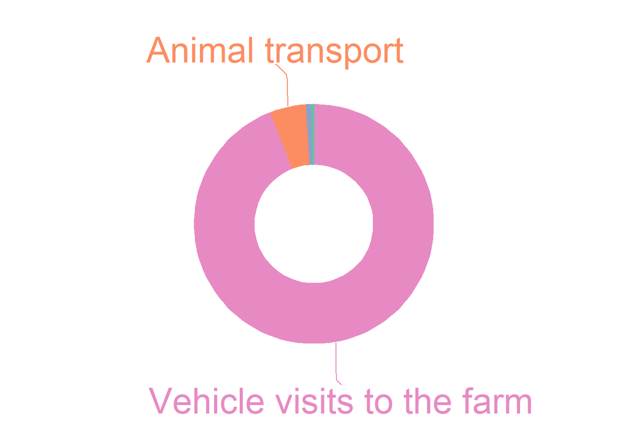

(a) IBR

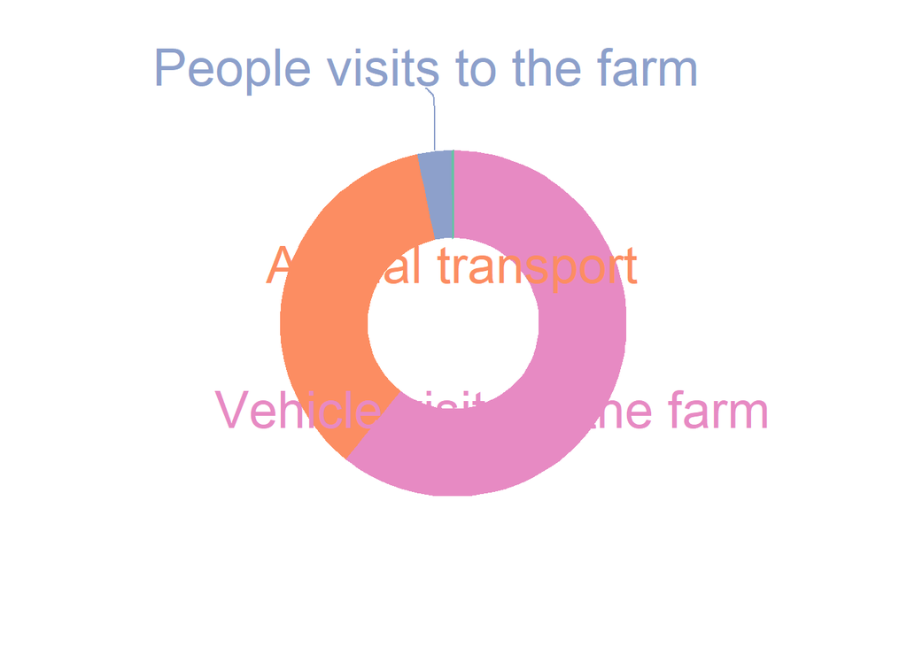

(b) BVD

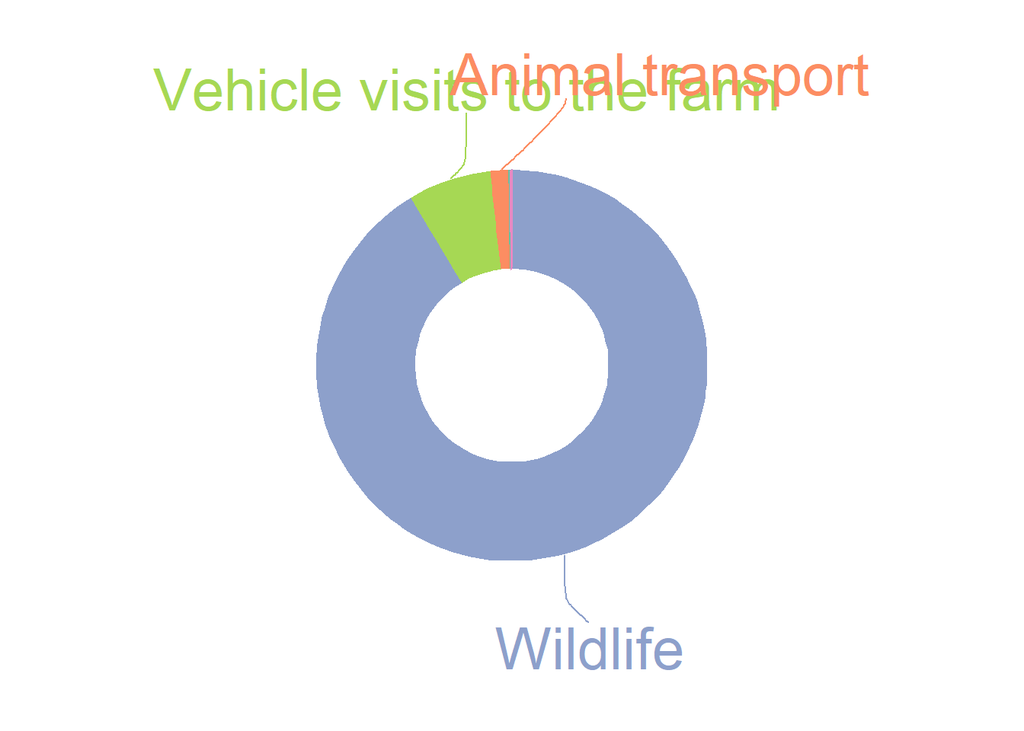

(c) TB

Figure 1.2: Risk of disease entry by pathway

## **Infectious Bovine Rhinotracheitis (IBR)**

### Current risk

Annual risk of IBR entry in the farm: **2.48%** (1.1-4.61%)

By pathway:

- Vehicle visits to the farm: **2.35%** (0.929-4.48%)
- Animal transport: **0.121%** (0.0731-0.179%)
- People visits to the farm: **0.0185%** (0.00912-0.0302%)
- Animals from other origin: **0.00702%** (0.00103-0.0273%)

### Risk reduction of biosecurity measures

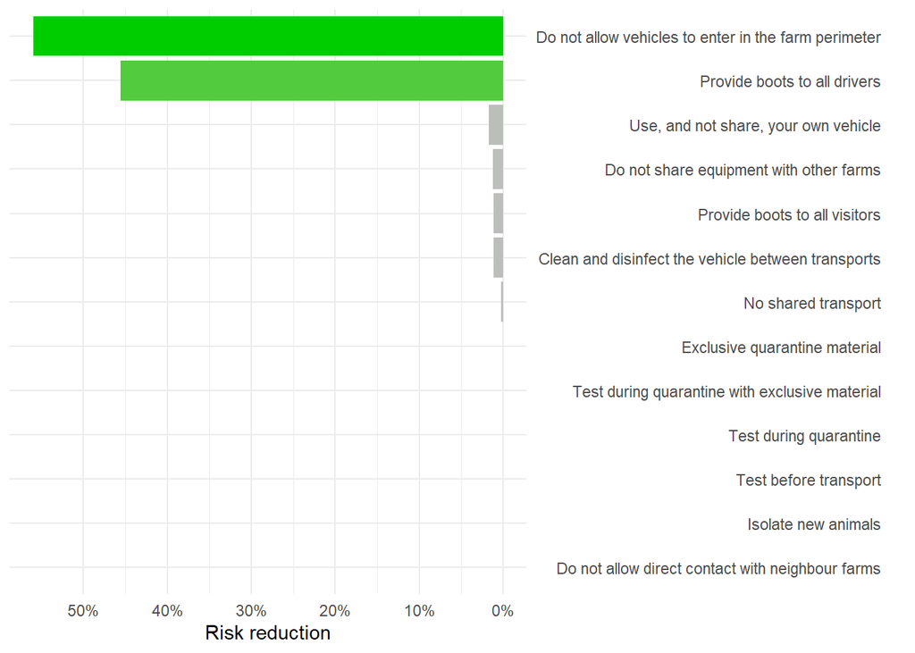

## **Bovine viral diarrhea (BVD)**

### Current risk

Annual risk of BVD entry in the farm: **2.17%** (1.3-3.3%)

By pathway:

- Vehicle visits to the farm: **1.33%** (0.55-2.4%)
- Animal transport: **0.79%** (0.385-1.15%)
- People visits to the farm: **0.0708%** (0.0306-0.143%)
- Animals from other origin: **0.00183%** (0.000209-0.00553%)

### Risk reduction of biosecurity measures

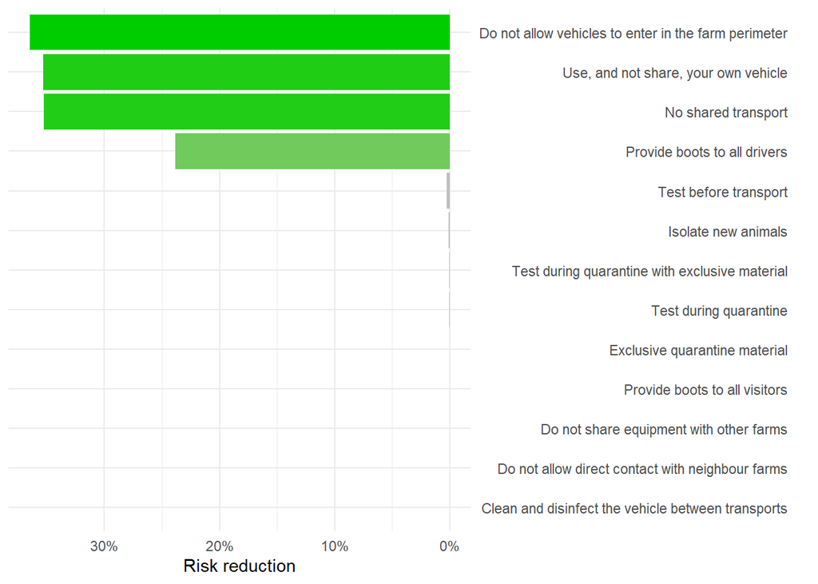

## **Bovine Tuberculosis (TB)**

### Current risk

Annual risk of TB entry in the farm: **0.0307%** (0.00672-0.121%)

By pathway:

- Wildlife: **0.0269%** (0.004-0.117%)
- Vehicle visits to the farm: **0.00202%** (0.00035-0.0108%)
- Animal transport: **0.000448%** (0.000281-0.000732%)
- Animals from other origin: **3.24e-05%** (2.27e-05-4.25e-05%)
- People visits to the farm: **2.7e-05%** (5.75e-06-8.96e-05%)

### Risk reduction of biosecurity measures

[figure not shown]

# 🐄 Description of the farm

## Farm information

**Location:** Cataluña, Spain

**Farm type:** Dairy cattle, NA

**Cattle cens:**

- 35 Calves ( <8 m)
- 10 Heifers (8 - 24 m)
- 24 Adult cows (>24 m)
- 1 Bulls

**Other animals in the farm:**

- **Direct contact with cattle:** 3 dogs, 18 cats
- **No direct contact with cattle:** 200 sheep, 100 pigs

**Neighbours**: No cattle farms within a 1-2km radious (negligible risk)

## Farm vehicles

| veh_id | Size | Shared | Cleaning |
| --- | --- | --- | --- |
| Remolc (c) | 5m2 | Shared with 1 cattle farms | From time to time |

## Visits

### People entering the barn

| Visit | Type | Frequency | Boots | Equipment | Risk |
| --- | --- | --- | --- | --- | --- |
| Veterinari reproducció | External veterinarians | 10 | Always used in other farms, unk cleaned and disinfected | Always used in other farms, always cleaned and disinfected | IBR: 0.0124%, BVD: 0.0452%, TB: 1.51e-05% |
| Podòleg | Other animal professionals (e.g. hoof trimmer) | 3 | Always used in other farms, unk cleaned and disinfected | Always used in other farms, always cleaned and disinfected | IBR: 0.00467%, BVD: 0.0187%, TB: 6.3e-06% |
| Veterinari sanejament | External veterinarians | 1 | Always used in other farms, always cleaned and disinfected | Always used in other farms, always cleaned and disinfected | IBR: 0.00119%, BVD: 0.00473%, TB: 1.64e-06% |

### Vehicles entering the farm perimeter

| Visit | Type | Frequency | Driver | Risk |
| --- | --- | --- | --- | --- |
| Escorxador vedells | Slaughterhouse vehicle | 30 | Enters areas used by farm animals (no contact with animals), boots always used in other farms, never cleaned and disinfected | IBR: 1.63%, BVD: 0.356%, TB: 0.00092% |
| Recría contractat | Calf transport vehicle | 3 | Contacts farm animals, boots always used in other farms, unk cleaned and disinfected | IBR: 0.419%, BVD: 0.863%, TB: 0.000505% |
| Escorxador vaques | Slaughterhouse vehicle | 4 | Enters areas used by farm animals (no contact with animals), boots always used in other farms, unk cleaned and disinfected | IBR: 0.128%, BVD: 0.0296%, TB: 8.87e-05% |
| Llet | Milk collection vehicle | 360 | - | IBR: 0.0657%, BVD: 0.012%, TB: 5.1e-06% |
| Cadàvers | Rendering vehicle | 104 | - | IBR: 0.037%, BVD: 0.00683%, TB: 2.89e-06% |
| Recría propi | Calf transport vehicle (own and not shared) | 3 | - | IBR: 0%, BVD: 0%, TB: 0% |

# 🚚 Movements

Animal movements in the last 12 months

| mov_id | When | Origin | Animals moved | Shared site | Vehicle used | Risk |
| --- | --- | --- | --- | --- | --- | --- |
| recurrente_recria | 🔁 Recurrent round: 3 times/year, out for 500 days | Other farm/s: Barcelona | 3 Heifers (8 - 24 m) | No | Own Remolc and External (shared journey) | IBR: 0.119%, BVD: 0.771%, TB: 0.000236% |
| terneros_austria | ➡️ One-off entry: 2024-05-01 | Other farm/s: Austria | 4 Calves ( <8 m) | - | External (shared journey) | IBR: 0.00834%, BVD: 0.00919%, TB: 0.000123% |
| recurrente_machos | ➡️ Recurrent entry: 1.25 times/year | Genetic selection centre: Austria | 3 Calves ( <8 m) | - | External (shared journey) | IBR: 0.00114%, BVD: 0.00652%, TB: 0.000109% |

### Health status and tests in origin

| mov_id | Pathogen | Health status in origin | Test in origin |
| --- | --- | --- | --- |
| recurrente_machos | BVD | BVD- (Officially free) | - |
|  | IBR | IBR4 (Officially free) |  |
|  | TB | T3H (Long-term officially free) |  |
| recurrente_recria | BVD | Unknown |  |
|  | IBR |  |  |
|  | TB |  |  |
| terneros_austria | BVD |  |  |
|  | IBR |  |  |
|  | TB |  |  |

### Quarantine

#### Characteristics

*No quarantine*

# 🐗 Wildlife

**Wildlife:** IBR: -, BVD: -, TB: 0.0269%

- Outdoors grazing: Outdoors grazing, no complete perimeter fence (electric) (IBR: -, BVD: -, TB: 0.0269%)
- Pasture (trashumance): No pastures

### Farm water points

| Waterpoints | Mud |
| --- | --- |
| 100% High waterer (>90cm) | 0% |
| 100% Waterhole | 100% |

### Pasture water points

*No pasture water points*

# Comments

- 25 vedells propis que engreixa a la seva granja (fins a 1 any) (complete)
- recurrente_machos: A confirmar estatus i tests. (complete)
- recurrente_recria: Numero animals aproximat (complete)

# Technical Annex

- Simulation date: 2025-11-17 12:53:59
- Script unification date: 2025-11-17 12:20:43
- Repository: https://github.com/NataliaCiria/biosecurity_model.git
- Last commit: 5b482c75a9928a4d9b1dd0f39f59ed7d93bb09e0
- Last commit date: 2025-11-16 17:22:55
- user_id:
- farm_id: bl1_v3_mod
- Risk timeframe: 360 days
- Calculate all summaries: FALSE
- Automatic what-if scenarios: TRUE
- Analyse model sensitivity: FALSE
- Farm biosecurity survey: bsg_cattle_v4_1_ciria 2014-10-10
- Movements surveys:
  - v4_1_ciria ( 3 ): recurrente_machos, recurrente_recria, terneros_austria